# Return

2025-03-03

This is the R markdown (rmd) exercise file that accompanies the lecture notes. It will be your sandbox! Fill in the R code chunks, experiment, and have fun!

# Data Preparation

### Import directly using quantmod

```r
library(quantmod)
stock_symbol <- "GS"
stock_data <- getSymbols(stock_symbol, auto.assign = FALSE)
```

# Price Return

### Price Return

See 2.1 of Ang’s text.

### Calculate Price Return By Definition

Calculate the daily price return on your stock by definition:

```r
Close <- Cl(stock_data)
price.return <- (Close - lag(Close)) / lag(Close)
head(price.return)
```

```
##                GS.Close
## 2007-01-03           NA
## 2007-01-04 -0.009316436
## 2007-01-05  0.001005768
## 2007-01-08  0.023511643
## 2007-01-09  0.001717990
## 2007-01-10  0.019747152
```

### Using Diff()

Use Diff() to calculate the daily price return of your stock:

```r
price.return <- diff(Close)/lag(Close)
head(price.return)
```

```
##                GS.Close
## 2007-01-03           NA
## 2007-01-04 -0.009316436
## 2007-01-05  0.001005768
## 2007-01-08  0.023511643
## 2007-01-09  0.001717990
## 2007-01-10  0.019747152
```

### Using Delt()

Use Delt() to calculate the daily price return of your stock:

```r
price.return <- Delt(Close)
head(price.return)
```

```
##            Delt.1.arithmetic
## 2007-01-03                NA
## 2007-01-04      -0.009316436
## 2007-01-05       0.001005768
## 2007-01-08       0.023511643
## 2007-01-09       0.001717990
## 2007-01-10       0.019747152
```

### Plot Price Return

Plot the price return of your stock:

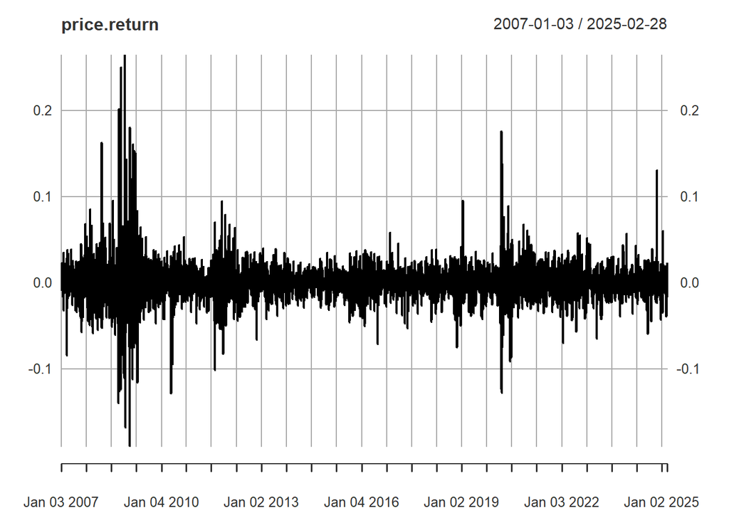

```r
plot(price.return)
```

# Total Return

### Total Return

Reading: Ch 2.2 of Ang’s text.

### Ex-dividend date

Google to find out the most recent ex-dividend date of your stock. (If a stock has never paid dividend, then the exercise here does not apply to the stock.)

Select a time window that include this ex-dividend date and print the stock prices in this time window:

```r
cbind(Cl(stock_data), Ad(stock_data))['2018-08-06/2018-08-11']
```

```
##            GS.Close GS.Adjusted
## 2018-08-06   235.93    202.0379
## 2018-08-07   237.83    203.6649
## 2018-08-08   236.37    202.4147
## 2018-08-09   233.78    200.1967
## 2018-08-10   229.61    196.6258
```

This explains how adjusted close is calculated:

https://help.yahoo.com/kb/SLN28256.html

What is your intuition for the adjustment?

### Calculate Total Return

Calcualte the total return on your stock.

```r
Adjusted <- Ad(stock_data)
total.return <- (Adjusted - lag(Adjusted)) / lag(Adjusted)
head(total.return)
```

```
##             GS.Adjusted
## 2007-01-03           NA
## 2007-01-04 -0.009315883
## 2007-01-05  0.001005506
## 2007-01-08  0.023511779
## 2007-01-09  0.001717536
## 2007-01-10  0.019747486
```

### Price Return vs. Total Return

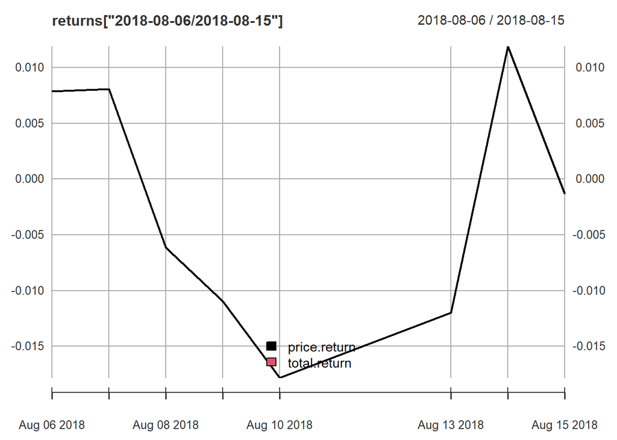

```r
returns <- cbind(price.return, total.return)
names(returns) <- c('price.return', 'total.return')
plot(returns['2018-08-06/2018-08-15'],
     legend.loc='bottom', major.ticks = "days")
```

### Adjusted Close vs. Unadjusted Close

Plot the adjusted close and unadjusted close of your stock:

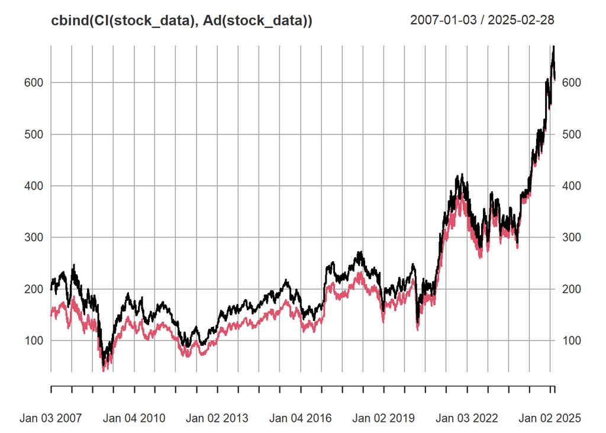

```r
plot(cbind(Cl(stock_data), Ad(stock_data)))
```

# Log Return

### Log Return

Reading: Ch 2.3 of Ang’s text.

### Calculate Log Return

Calculate and plot the log return for your stock:

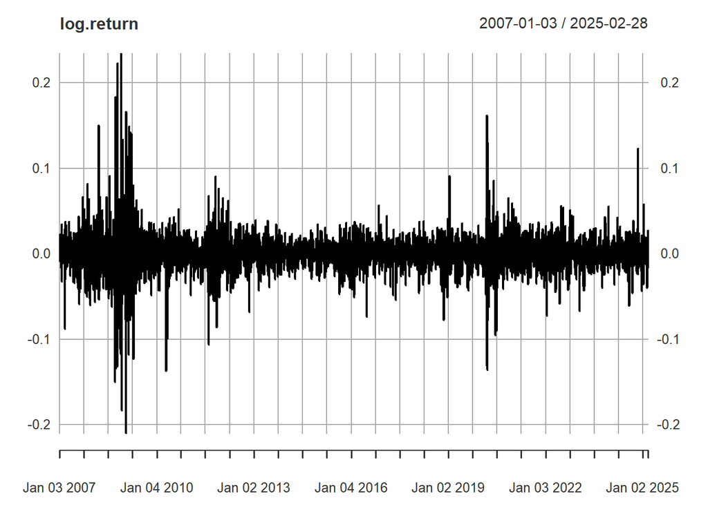

```r
log.return <- diff(log(Ad(stock_data)))
plot(log.return)
```

### Log Return and Total Return

Compare log return to total return. How close are they? They are very close

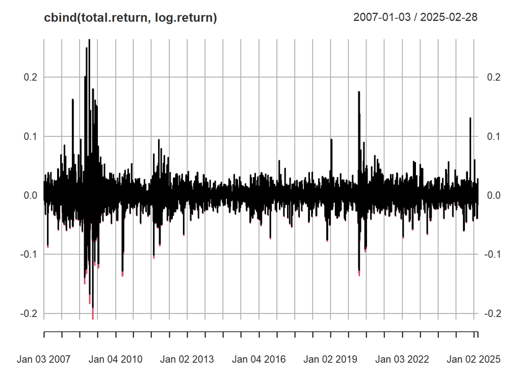

```r
plot(cbind(total.return, log.return))
```

# Cumulative Return

### Cumulative Return

Reading: Ch 2.4 of Ang’s text.

### Calculating Gross Return

Calculate the gross return:

```r
gross.return <- total.return + 1
head(gross.return)
```

```
##            GS.Adjusted
## 2007-01-03          NA
## 2007-01-04   0.9906841
## 2007-01-05   1.0010055
## 2007-01-08   1.0235118
## 2007-01-09   1.0017175
## 2007-01-10   1.0197475
```

### Calculating Cumulative Return

Calculate the cumulative return:

```r
gross.return[1] <- 1
cumulative.return <- cumprod(gross.return)
head(cumulative.return)
```

```
##            GS.Adjusted
## 2007-01-03   1.0000000
## 2007-01-04   0.9906841
## 2007-01-05   0.9916803
## 2007-01-08   1.0149964
## 2007-01-09   1.0167397
## 2007-01-10   1.0368178
```

### Plot the cumulative return

Plot the cumulative return:

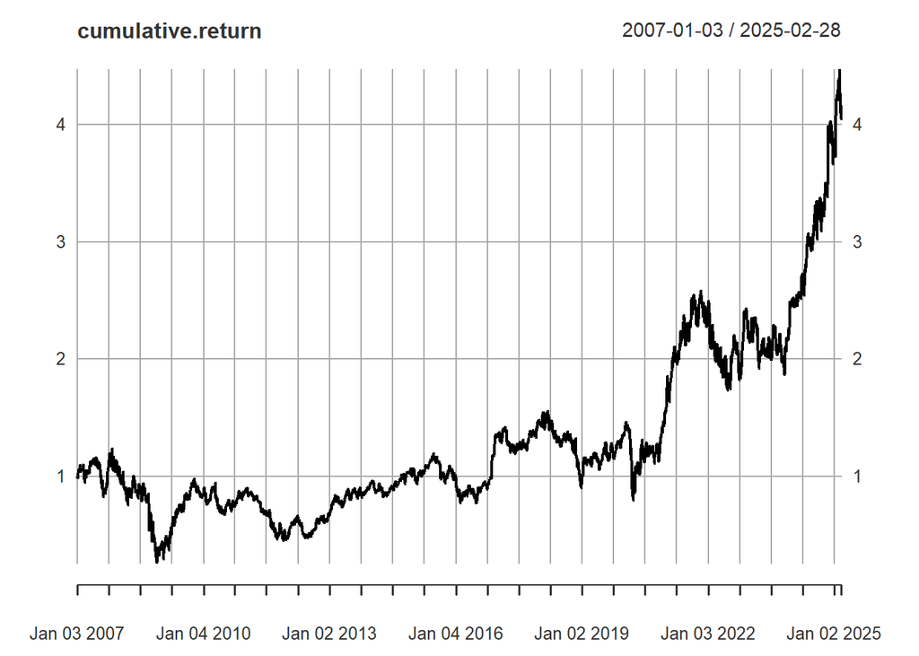

```r
plot(cumulative.return)
```

How does it compare to the normalized price path?

# Monthly Return

### Monthly Return

Use to.monthly() to convert daily prices to monthly prices:

```r
monthly.price <- to.monthly(Adjusted)
head(monthly.price)
```

```
##          Adjusted.Open Adjusted.High Adjusted.Low Adjusted.Close
## Jan 2007      149.6563      164.3804     148.2621       158.4504
## Feb 2007      158.3309      165.0078     146.3815       150.6758
## Mar 2007      149.1149      158.2489     141.9004       154.3204
## Apr 2007      153.5885      168.7574     153.5885       163.5286
## May 2007      163.5061      173.5448     163.5061       172.6621
## Jun 2007      172.5798      174.7716     160.2073       162.1372
```

### Select the end-of-month prices

Select the end-of-month prices:

```r
monthly.Close <- monthly.price[,4]
names(monthly.Close) <- paste0(stock_symbol, ".Close")
head(monthly.Close)
```

```
##          GS.Close
## Jan 2007 158.4504
## Feb 2007 150.6758
## Mar 2007 154.3204
## Apr 2007 163.5286
## May 2007 172.6621
## Jun 2007 162.1372
```

### Calculate Monthly Return

Calculate monthly returns:

```r
monthly.return <- Delt(monthly.Close)
names(monthly.return) <- stock_symbol
head(monthly.return)
```

```
##                   GS
## Jan 2007          NA
## Feb 2007 -0.04906653
## Mar 2007  0.02418830
## Apr 2007  0.05966930
## May 2007  0.05585271
## Jun 2007 -0.06095664
```

# Empirical Facts

### Empirical Facts

Remove the NA of your stock returns:

```r
r <- na.omit(monthly.return)
head(r)
```

```
##                   GS
## Feb 2007 -0.04906653
## Mar 2007  0.02418830
## Apr 2007  0.05966930
## May 2007  0.05585271
## Jun 2007 -0.06095664
## Jul 2007 -0.12951146
```

### Monthly Return

Plot the monthly returns:

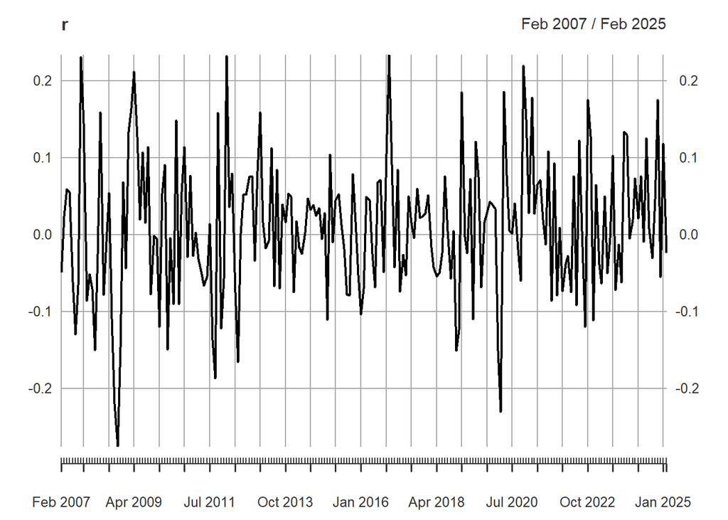

```r
plot(r)
```

## Summary Statistics

### summary()

Find the the first quartile, median, and the third quartile of the stock returns:

```r
summary(r)
```

```
##      Index            GS
##  Min.   :2007   Min.   :-0.275139
##  1st Qu.:2012   1st Qu.:-0.052854
##  Median :2016   Median : 0.009393
##  Mean   :2016   Mean   : 0.010328
##  3rd Qu.:2021   3rd Qu.: 0.068852
##  Max.   :2025   Max.   : 0.234121
```

Find the range and interquartile range of the stock returns:

```r
range(r)
```

```
## [1] -0.2751389  0.2341205
```

```r
IQR(r)
```

```
## [1] 0.1217057
```

### Box Plot

Make the box plot of your stock’s returns:

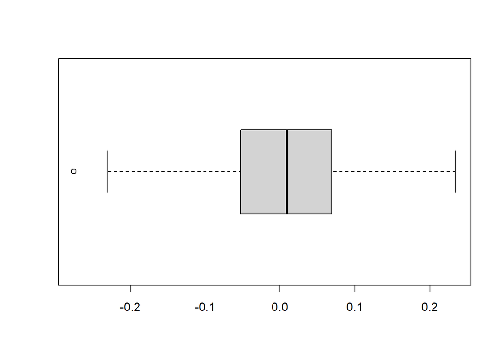

```r
boxplot(as.vector(r), horizontal = TRUE)
```

Understanding box plot: http://onetipperday.sterding.com/2012/06/about-boxplot.html

### Mean

Calculate the average return of your stock:

```r
mean(r)
```

```
## [1] 0.0103276
```

### Variance

Calculate the variance of stock return:

```r
var(r)
```

```
##             GS
## GS 0.008037029
```

### Standard Deviation

Calculate the standard deviation of stock returns:

```r
sd(r)
```

```
## [1] 0.08964948
```

## Are returns normally distributed?

### Histogram

Plot the histogram of the monthly stock return:

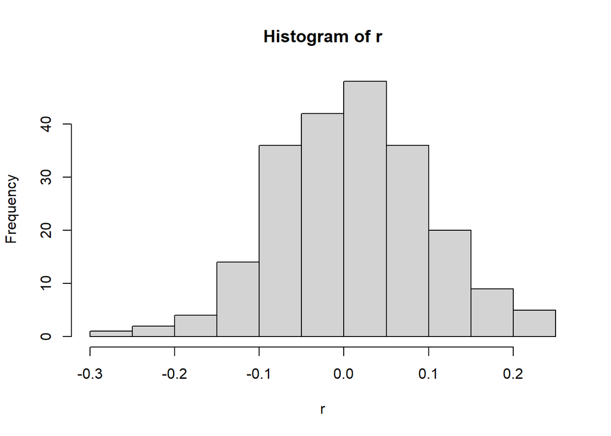

```r
hist(r)
```

Readings:

https://www.statmethods.net/graphs/density.html

https://www.r-bloggers.com/basics-of-histograms/

### Change the number of bins

Experiment with the “breaks” option for hist():

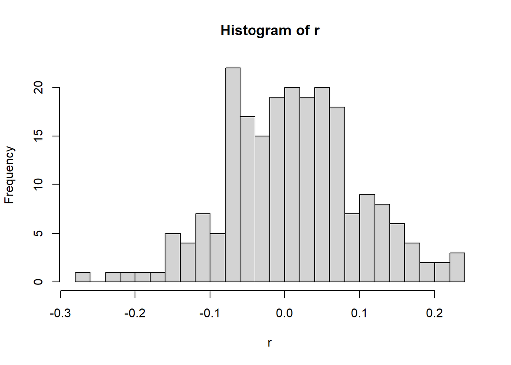

```r
hist(r, breaks = 20)
```

### Frequency vs Density

Plot the density instead of frequency:

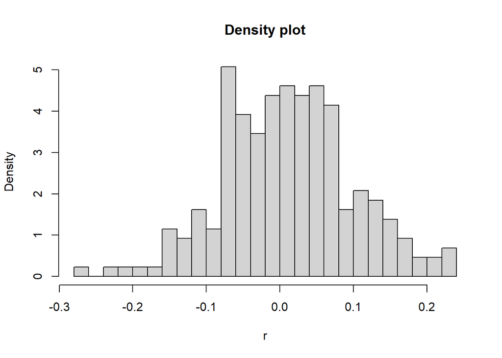

```r
hist(r, breaks = 20, freq = FALSE, main = "Density plot")
```

### Kernel Density

Estimate the kernel density and plot it over the histogram:

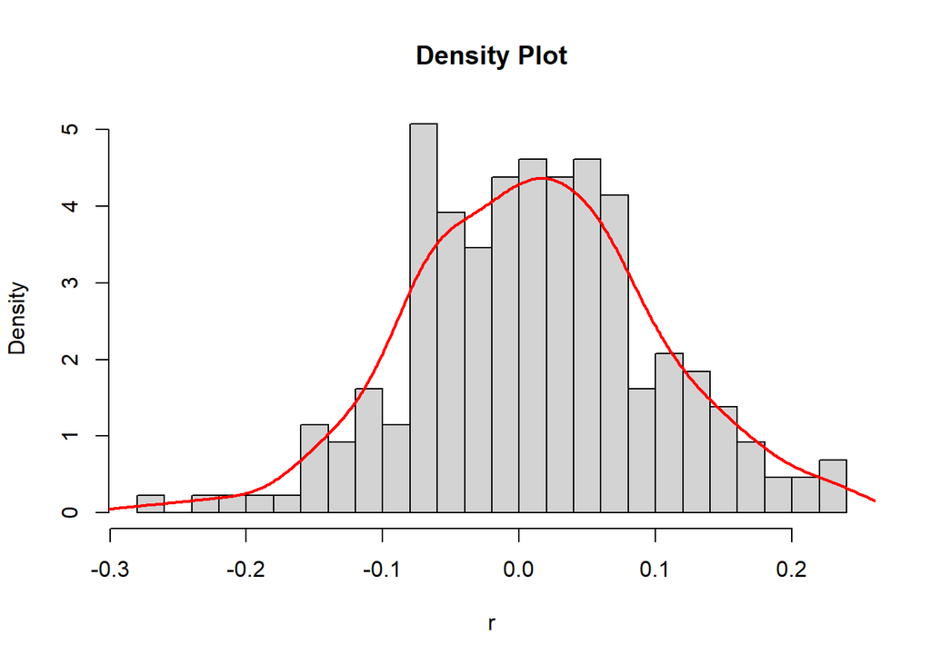

```r
hist(r, breaks = 20, freq = FALSE, main = "Density Plot")
lines(density(r), col='red', lwd = 2)
```

### Add a Normal Curve

Find help on curve() and dnorm() and use them to plot a normal density on top of the histogram.

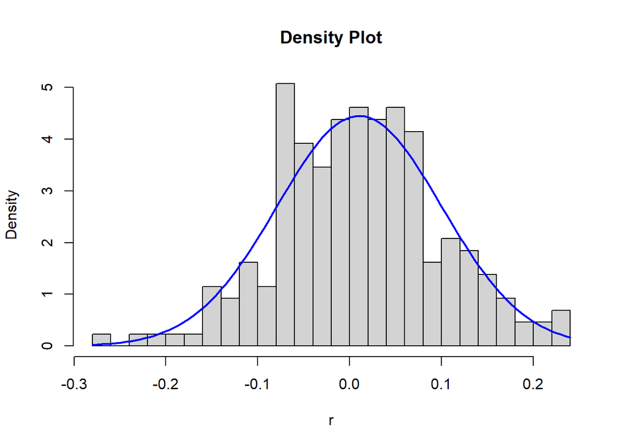

```r
hist(r, breaks = 20, freq = FALSE, main = "Density Plot")
curve(dnorm(x, mean = mean(r, na.rm = TRUE), sd = sd(r, na.rm = TRUE)),
      col = "blue", lwd = 2, add = TRUE)
```

Use quantile() to return the first quartile, median, and the third quartile of the stock returns:

```r
quantile(r)
```

```
##           0%          25%          50%          75%         100%
## -0.275138948 -0.052854117  0.009393231  0.068851563  0.234120522
```

Reading: http://www.r-tutor.com/elementary-statistics/numerical-measures/quartile

### quantile

Find the 5% and 95% quantiles of your stock returns.

```r
quantile(r,c(0.05,0.95))
```

```
##         5%        95%
## -0.1308723  0.1601924
```

Reading: http://www.r-tutor.com/elementary-statistics/numerical-measures/percentile

In spreadsheet, it is accomplished using percentile().

### QQ plot

Make a QQ plot of the stock returns agains a random sample that is normally distributed with the same mean and standard deviation:

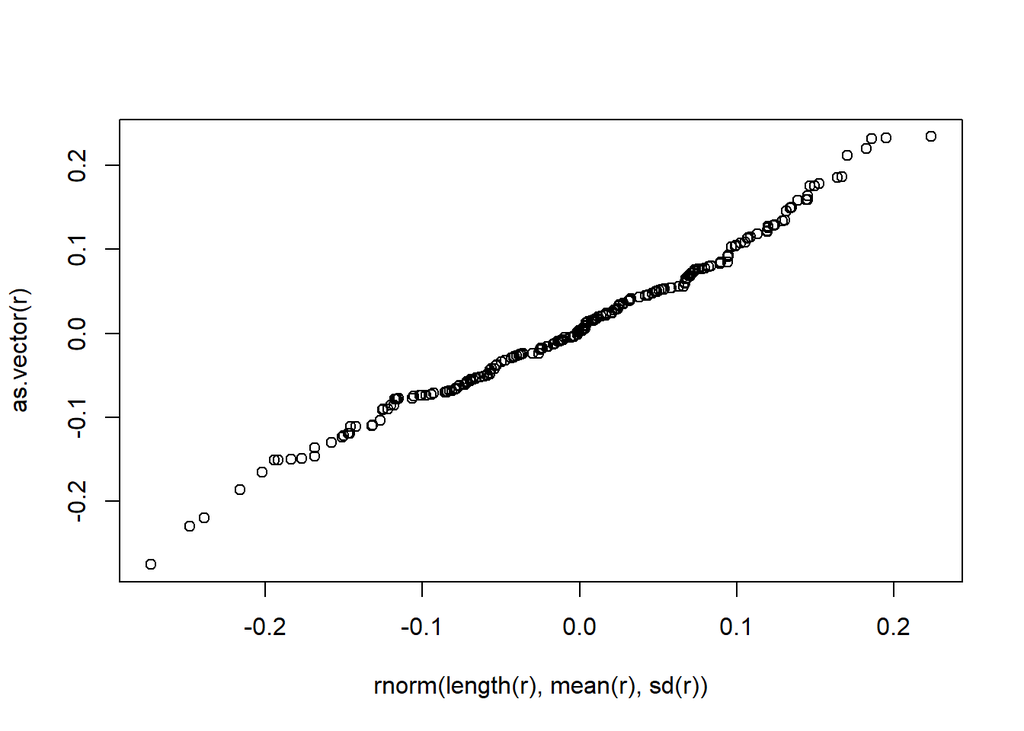

```r
qqplot(rnorm(length(r), mean(r), sd(r)), as.vector(r))
```

Reading: https://www.dummies.com/programming/r/how-to-use-quantile-plots-to-check-data-normality-in-r/

### QQ plot to check normality

Use qqnorm() to make QQ plot. Are returns normally distributed? Yes

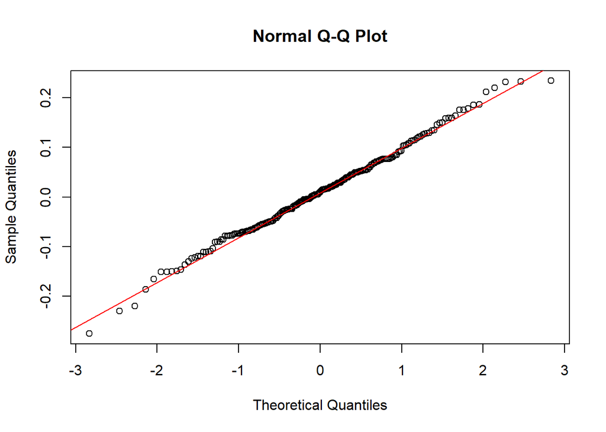

```r
qqnorm(r)
qqline(r, col = "red")
```

### Skewed Distributions

Reading: https://whatis.techtarget.com/definition/skewness

### Measuring Skewness

Calculate the skewness of your stock’s returns. You may need to install the e1071 package first.

```r
library(e1071)
skewness(r)
```

```
## [1] -0.00207911
```

### Kurtosis

Calculate the kurtosis of your stock’s returns.

```r
kurtosis(r)
```

```
## [1] 0.1729033
```

## Return Predictability

### Return Predictability

Make a scatter plot of the stock return against its lag:

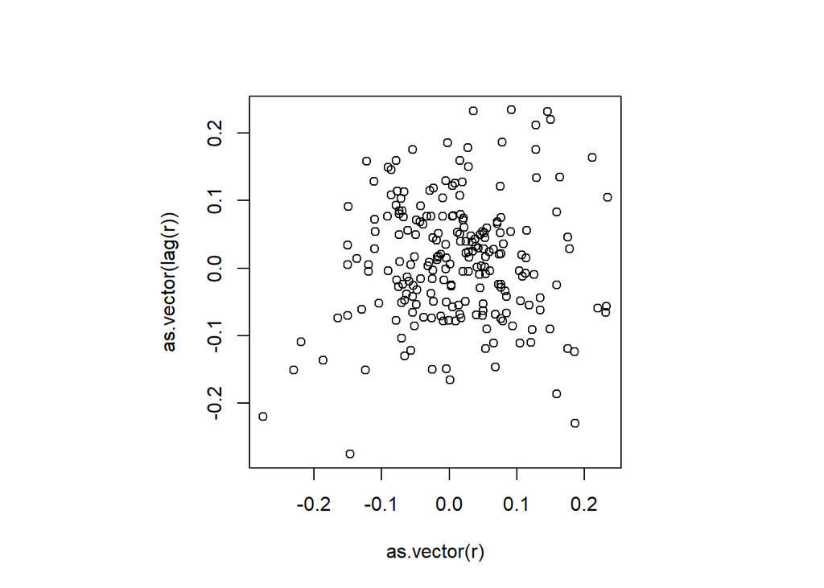

```r
par(pty="s")
plot(as.vector(r), as.vector(lag(r)))
```

Do past returns predict future returns according to the scatter plot?

### Autocorrelation

Compute the correlation of the return against its lag.

```r
cor(r[2:length(r)], lag(r)[2:length(r)])
```

```
##            GS
## GS 0.06782509
```

### ACF

Use acf() to plot the autocorrelations:

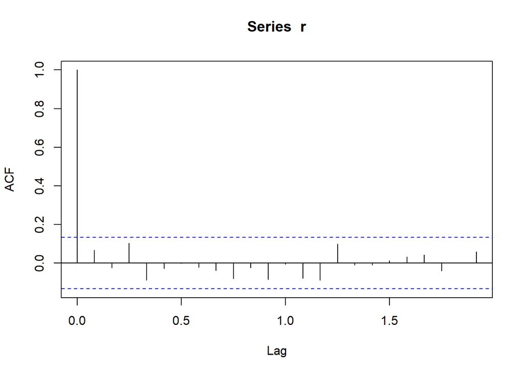

```r
acf(r)
```

What are your findings?

Reading: https://programming-r-pro-bro.blogspot.com/2011/10/predictability-of-stock-returns-using_28.html

### Rolling Volatility

Calcualte the rolling volatility of daily stock returns and intepret:

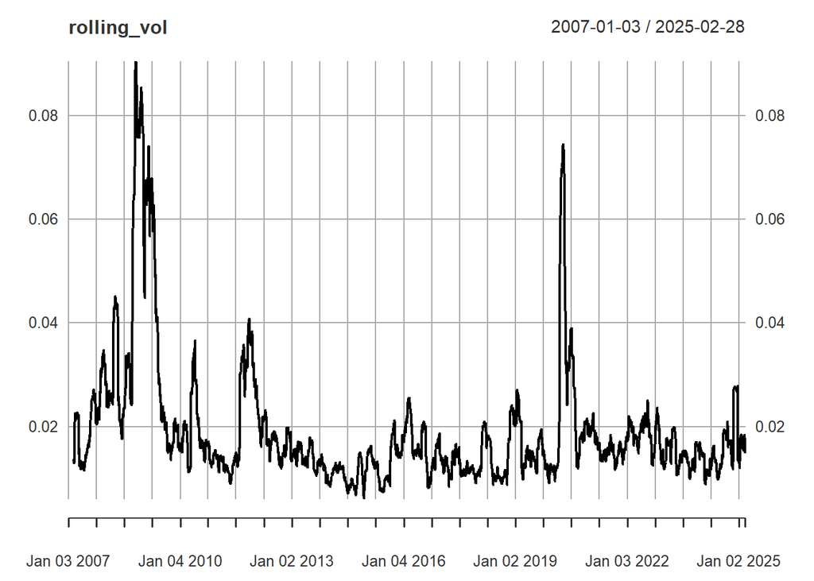

```r
rolling_vol <- rollapply(total.return, width = 30, FUN = sd)
plot(rolling_vol)
```

rollapply() is a very useful function that can be used to calculate rolling sum, rolling mean, etc.

### CBOE Volatility Index (VIX)

Reading: http://www.cboe.com/vix

### Getting VIX Data

The VIX data can be downloaded from: https://www.cboe.com/tradable_products/vix/vix_historical_data/

(If the above link doesn’t work, you may need to Google to find out the correct link.)

Download and import the VIX data. (Note: when downloading the data, right click the download link and “save link as” to save to file to the same folder as your rmd file. Do not open the csv file in Excel to save it to a directory since this will mess up the file format.)

```r
vix_data <- read.csv("VIX_History.csv", header = TRUE)
```

### Historical VIX

Plot the historical VIX. Do you see time-varying volatility?

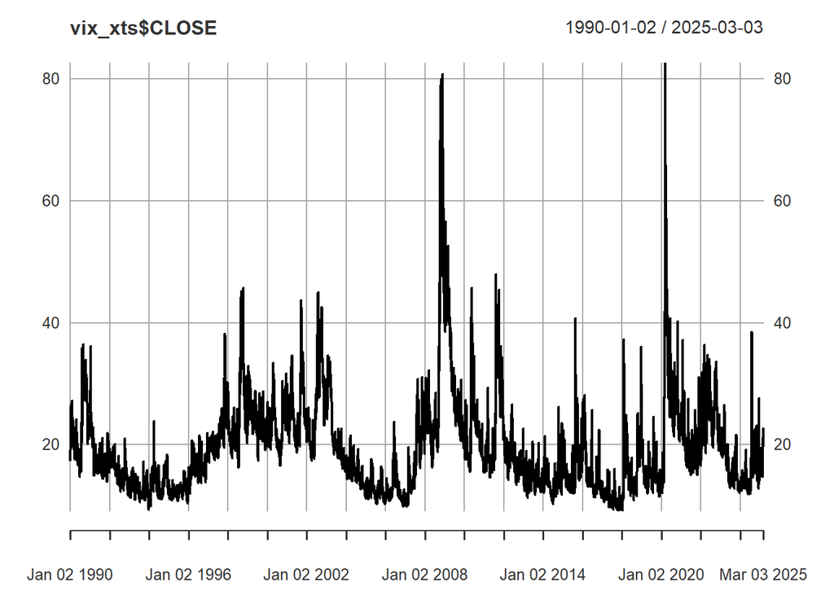

```r
vix_data$DATE <- as.Date(vix_data$DATE, format = "%m/%d/%Y")
vix_xts <- xts(vix_data[,2:5], order.by=vix_data[,1])
plot(vix_xts$CLOSE)
```